# Sampling bias in radiocarbon dating project: broad approach 1 using the AustArch database

Rebecca Wheatley

5 May 2021

## Set up

Load required packages:

```r
library(ggformula)
library(plyr)
library(tidyverse)
library(data.table)
library(rcarbon)
library(parallel)
```

Specify path for source functions:

```r
source("C:/Users/Bec/Work/Projects/Radiocarbon dating/GitHub/Analysis/broad_approach_1-source.R")
```

Load the AustArch data and make sure relevant columns read in correctly:

```r
AustArch <- read.csv("C:/Users/Bec/Work/Projects/Radiocarbon dating/GitHub/Data/Austarch_1-3_and_IDASQ_28Nov13-1.csv")
AustArch$AGE_NORM     <- as.numeric(AustArch$AGE_NORM)
AustArch$ERROR        <- as.numeric(AustArch$ERROR)
AustArch$LATITUDE     <- as.numeric(AustArch$LATITUDE)
AustArch$LONGITUDE    <- as.numeric(AustArch$LONGITUDE)
AustArch$IBRA_REGION  <- as.factor(AustArch$IBRA_REGION)
AustArch$SITE         <- as.factor(AustArch$SITE)
```

Get rid of:  
* "unusable" samples * samples missing an age and/or error estimate  
* samples generated using any method that is not radiocarbon dating (this should be anything < 400 years BP for marine samples, and < 200 years for terrestrial samples)  
* samples that fall outside of the calibration age range * samples that fall outside of the age range we are interested in (in this case, we only want Holocene dates)

```r
data <- AustArch %>%
  dplyr::filter(Data.pertinent.for.time.series.analysis.or.calibration != "Unusuable") %>%
  dplyr::filter(AGE_NORM != "NA") %>%
  dplyr::filter(ERROR != "NA") %>%
  dplyr::filter(METHOD == "Radiocarbon") %>%
  dplyr::filter((AGE_NORM >= 400 & Data.pertinent.for.time.series.analysis.or.calibration == "Marine")
                | (AGE_NORM >= 200 & Data.pertinent.for.time.series.analysis.or.calibration == "Terrestrial")) %>%
  subset(AGE_NORM <= 12000)
```

Create a new column that records the number of dated samples available for that site: NO_DATES_PER_SITE

```r
data <- data %>%
  dplyr::arrange(SITE) %>%
  dplyr::group_by(SITE, .drop = TRUE) %>%
  dplyr::mutate(DATES_PER_SITE = length(AGE_NORM))
```

Create a new column that records a sample's position in the time series of the youngest dated sample at that site (1) to the oldest dated sample at that site (NO_DATES_PER_SITE): POSITION_IN_SERIES

```r
data <- data %>%
  dplyr::arrange(SITE, AGE_NORM)
position <- vector(length = nrow(data))
for (i in 1:nrow(data)) {
  ## if we're not in row 1
  if (i > 1)
  {
    ## if the site in this row is the same as the site in the previous row
    if (data$SITE[i] == data$SITE[i-1]) {
      position[i] <- position[i-1] + 1 ##
      ## if the site in this row is NOT the same as the site in the previous row
    } else {
      position[i] <- 1
    }
  } else { position[i] <- 1}
}
data$POSITION_IN_SERIES <- position
```

Create a new data set that contains only sites which have at least 5 samples. This will be our "baseline" data set, which we assume contains relatively little by way of sampling bias. We can then compare the results of common analysis methods (summed probability distributions, frequency distributions) using the baseline data set to those using various subsets of the baseline data which introduce known sampling biases.

```r
baseline.data <- data %>%
  subset(DATES_PER_SITE >= 5)
glimpse(data)
```

```
## Rows: 3,708
## Columns: 29
## Groups: SITE [1,529]
## $ ADSID                                                  <int> 10263, 10264, 1~
## $ IBRA_REGION                                            <fct> Broken Hill Com~
## $ LONGITUDE                                              <dbl> 143.6, 143.6, 1~
## $ LATITUDE                                               <dbl> -30.8, -30.8, -~
## $ SITE                                                   <fct> "11_18021 (Clus~
## $ SITE_TYPE                                              <chr> "Hearth", "Hear~
## $ LAB_CODE                                               <chr> "Wk-19580/NZA 2~
## $ AGE                                                    <chr> "1321", "1587",~
## $ ERROR                                                  <dbl> 46, 37, 38, 34,~
## $ C13_AGE                                                <dbl> NA, NA, NA, NA,~
## $ C13_ERROR                                              <dbl> NA, NA, NA, NA,~
## $ MATERIAL                                               <chr> "Charcoal", "Ch~
```

[output cut: 17 more lines]

## Generate and calibrate repeated sub-samples of the data to explore the effect of different sampling biases

We will run several sampling methods on the baseline data set to investigate different potential biases in radiocarbon dating sampling. These sampling methods are:  
1. **Uniform**. For each site (or some % of sites), choose a number of samples (`sampling_effort`) from a uniform distribution  
2. **Singleton**. For each site (or some % of sites), choose one sample. There are three methods of choosing which sample to use:  
+ the most **ancient** sample  
+ the most **recent** sample  
+ a **random** sample  
3. **Bracketed**. For each site (or some % of sites), choose the most recent and the most ancient sample

There are, therefore, two new parameters for subsampling the baseline data: `percent_sites` and `sampling_effort`. These determine the percent of sites we apply the sampling methods to and the number of samples we want to select if using a uniform sampling method.

```r
percent_sites   = 50   ## the number of sites we want to apply the sampling method across (the remainder will be
                       ## exhaustively sampled)
sampling_effort = 5    ## the number of samples we want to take using the uniform sampling method
nsim            = 20   ## the number of replicates to make when sampling
```

Using these parameters, generate `nsim` replicates of the data using the sampling method specified and calibrate:

```r
sample.uniform           <- get_samples(evidence = baseline.data,
                                        sampling_method = "uniform",
                                        sampling_effort = sampling_effort,
                                        percent_sites = percent_sites,
                                        nsim = nsim)

sample.singleton.ancient <- get_samples(evidence = baseline.data,
                                        sampling_method = "singleton_ancient",
                                        sampling_effort = sampling_effort,
                                        percent_sites = percent_sites,
                                        nsim = nsim)

sample.singleton.recent  <- get_samples(evidence = baseline.data,
                                        sampling_method = "singleton_recent",
                                        sampling_effort = sampling_effort,
                                        percent_sites = percent_sites,
                                        nsim = nsim)

sample.singleton.random  <- get_samples(evidence = baseline.data,
                                        sampling_method = "singleton_random",
                                        sampling_effort = sampling_effort,
                                        percent_sites = percent_sites,
                                        nsim = nsim)

sample.bracketed         <- get_samples(evidence = baseline.data,
                                        sampling_method = "bracketed",
                                        sampling_effort = sampling_effort,
                                        percent_sites = percent_sites,
                                        nsim = nsim)
```

Calibrate the baseline and sample data (using the `'rcarbon` package):

```r
normalised      = TRUE ## are calibration curves (and, later, SPDs) normalised?
cl              = detectCores()
ncores          = cl   ## the number of threads to use when calibrating the radiocarbon dates

# Baseline data
baseline.T  <- baseline.data %>% subset(Data.pertinent.for.time.series.analysis.or.calibration == "Terrestrial")
baseline.M  <- baseline.data %>% subset(Data.pertinent.for.time.series.analysis.or.calibration == "Marine")
cal.baseline.T    <- rcarbon::calibrate(x = baseline.T$AGE_NORM,
                                        errors = baseline.T$ERROR,
                                        ids = baseline.T$ADSID,
                                        calCurves = 'shcal20',
                                        normalised = normalised,
                                        ncores = ncores)
cal.baseline.M    <- rcarbon::calibrate(x = baseline.M$AGE_NORM,
                                        errors = baseline.M$ERROR,
                                        ids = baseline.M$ADSID,
                                        calCurves = 'marine20',
                                        normalised = normalised,
                                        ncores = ncores)
cal.baseline.data <- combine(cal.baseline.T, cal.baseline.M)


# Subsampled data
cal.uniform           <- calibrate_samples(samples = sample.uniform,
                                           normalised = normalised,
                                           ncores = ncores)

cal.singleton.ancient <- calibrate_samples(samples = sample.singleton.ancient,
                                           normalised = normalised,
                                           ncores = ncores)

cal.singleton.recent  <- calibrate_samples(samples = sample.singleton.recent,
                                           normalised = normalised,
                                           ncores = ncores)

cal.singleton.random  <- calibrate_samples(samples = sample.singleton.random,
                                           normalised = normalised,
                                           ncores = ncores)

cal.bracketed         <- calibrate_samples(samples = sample.bracketed,
                                           normalised = normalised,
                                           ncores = ncores)
```

## Generate and compare summed probability distributions (SPDs)

```r
timeRange = c(12000, 0) ## time range we want our SPDs to cover
runm = 100              ## the running mean to use for the SPDs

spd.uniform           <- compare_spds(calibrated_evidence = cal.baseline.data,
                                      calibrated_samples = cal.uniform,
                                      timeRange = timeRange,
                                      runm = runm,
                                      normalised = normalised)

spd.singleton.ancient <- compare_spds(calibrated_evidence = cal.baseline.data,
                                      calibrated_samples = cal.singleton.ancient,
                                      timeRange = timeRange,
                                      runm = runm,
                                      normalised = normalised)

spd.singleton.recent  <- compare_spds(calibrated_evidence = cal.baseline.data,
                                      calibrated_samples = cal.singleton.recent,
                                      timeRange = timeRange,
                                      runm = runm,
                                      normalised = normalised)

spd.singleton.random  <- compare_spds(calibrated_evidence = cal.baseline.data,
                                      calibrated_samples = cal.singleton.random,
                                      timeRange = timeRange,
                                      runm = runm,
                                      normalised = normalised)

spd.bracketed         <- compare_spds(calibrated_evidence = cal.baseline.data,
                                      calibrated_samples = cal.bracketed,
                                      timeRange = timeRange,
                                      runm = runm,
                                      normalised = normalised)
```

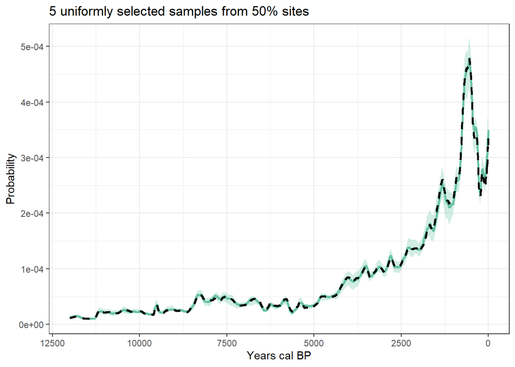

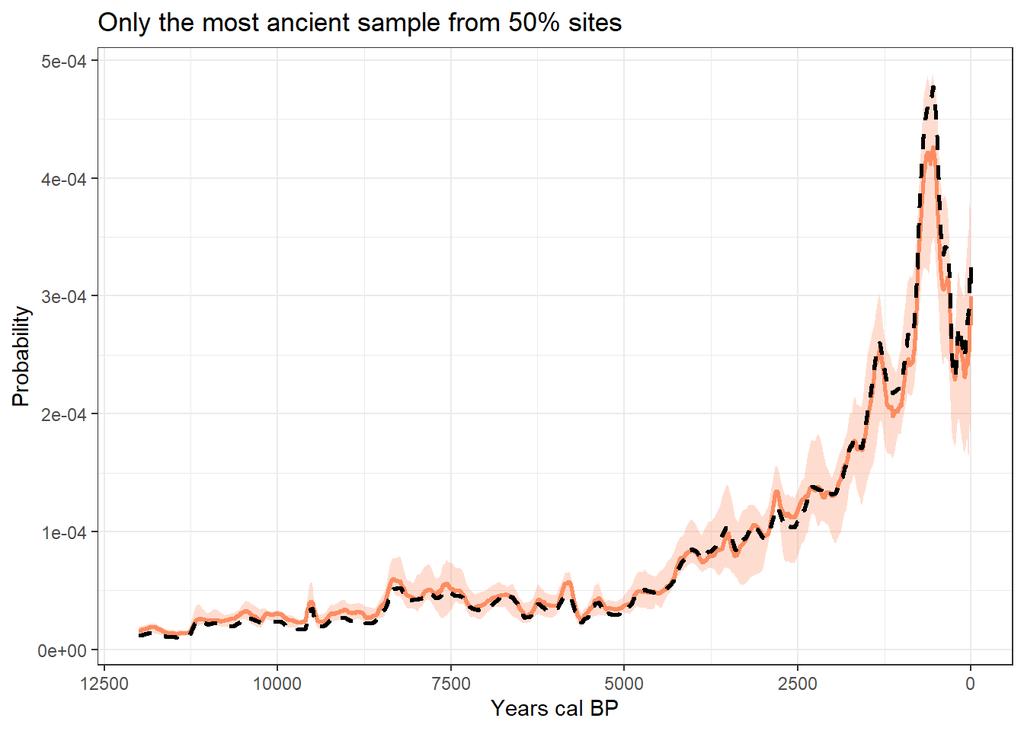

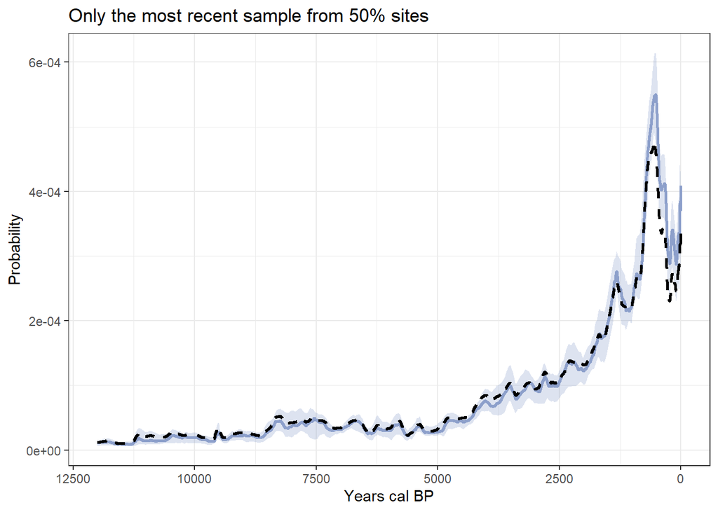

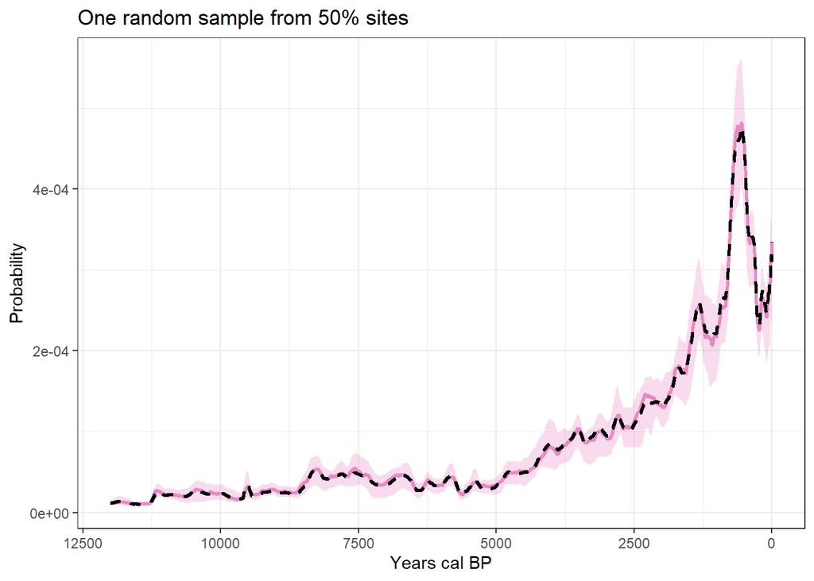

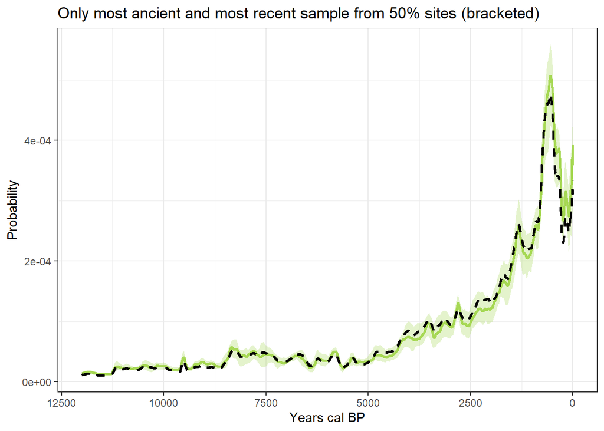

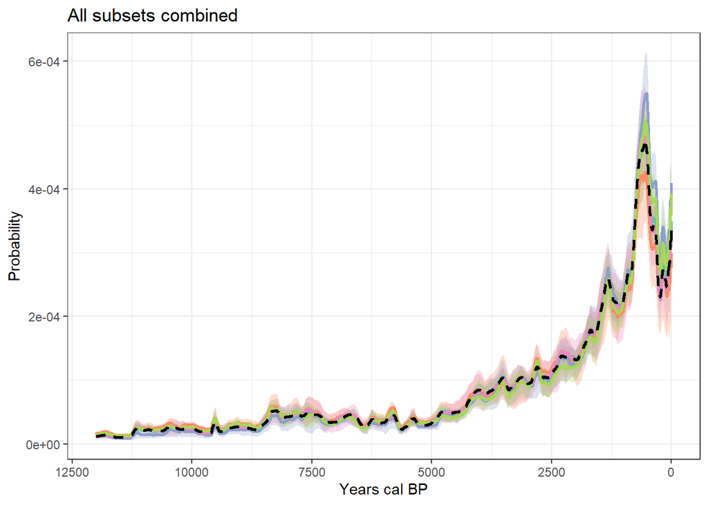